# Domača naloga 6

Natasa Kejzar

11.3.2018

# Naloga 6

Radi bi raziskali, kako je z dualnostjo binomskega eksaktnega testa ($\alpha = 0.05$) in naslednjih 95% intervalov zaupanja (IZ)

- Clopper–Pearsonov (eksaktni) IZ
- aproksimativni IZ za delež (z normalno porazdelitvijo)
1. Zapišite ničelno domnevo za dvostranski binomski eksaktni test.
2. Zapišite, kratko izpeljavo za izračun aproksimativnega IZ za delež (t.j. intervala zaupanja, ki ga izračunate, če binomsko porazdelitev aproksimirate z normalno).
3. V R definirajte funkcijo za izračun aproksimativnega IZ
4. S simulacijami (10.000 ponovitev) preverite, v kakšnem deležu binomski eksaktni test in obe različici intervala zaupanja zavračajo $H_0$. Vzorce generirajte pod $H_0$ za naslednji različici parametrov.
- $n=100, \pi = 0.5$ in $n=20, \pi = 0.5$ ter
- $n=100, \pi = 0.08$.

Deleže zavrnitev prikažite na enem grafu in rezultate vsake različice posebej utemeljite.

5. Simulirajte (št. ponovitev naj bo 1000) in grafično predstavite deleže zavrnitev vseh treh metod glede na $\pi$ na enem grafu. Vrednost drugega parametra naj bo $n=100$. Utemeljite/komentirajte rezultate.
6. Glede na rezultate, kako mislite, da bi se razlikovali (a) rezultati in (b) ugotovitve, če bi delali simulacije za 99% interval zaupanja? Utemeljite.

## 1. Ničelna domneva za dvostranski test

$$H_0: \pi = \pi_0$$

## 2. Izpeljava aproksimativnega IZ

Spremenljivka za delež pod $H_0$ je porazdeljena $X \sim \frac{1}{n}Bin(n,\pi_0)$. To aproksimiramo z normalno porazdelitvijo, ki ima parametra $\mu = E(X)$ in $\sigma = \sqrt{var(X)}$, torej
$$X \sim_{\mbox{approx}} N\left(\pi_0, \sqrt{\frac{\pi_0(1-\pi_0)}{n}}\right).$$
Interval zaupanja bo tako:
$$\left[p-z_{1-\frac{\alpha}{2}}\sqrt{\frac{\pi_0(1-\pi_0)}{n}},p+z_{1-\frac{\alpha}{2}}\sqrt{\frac{\pi_0(1-\pi_0)}{n}}\right],$$
kjer je $p$ delež na vzorcu.

## 3. Funkciji IZ

```r
# Clopper-Pearson IZ
IZ.bin <- function(delez,n,alpha){
  x = delez*n
  p.L <- function(x, alpha) {
    if (x == 0)
     0
    else qbeta(alpha, x, n - x + 1)
  }
  p.U <- function(x, alpha) {
    if (x == n)
      1
    else qbeta(1 - alpha, x + 1, n - x)
  }
  c(p.L(x,alpha/2),p.U(x,alpha/2))
}

# aproksimativni IZ
IZ.norm <- function(delez,n,alpha){
  SE = sqrt(delez*(1-delez)/n)
  p.L = delez + qnorm(alpha/2)*SE
  p.U = delez + qnorm(1-alpha/2)*SE
  c(p.L,p.U)
}
```

## 4. Simulacije za delež zavrnjenih hipotez za binomski eksaktni test in oba IZ

```r
# funkcija za preverjanje, ali je pi0 v IZ
vIntervalu <- function(iz,pi0){
  (pi0>=iz[1] & pi0<=iz[2])
}
simuliraj = function(n,p0,alfa=0.05,runs=10000){
  # na istih vzorcih izracunamo ujemanje za CP in A interval
  zavrni = numeric(runs)
  IZcp = numeric(runs)
  IZa = numeric(runs)
  for(i in 1:runs){
    vzorec=rbinom(1,n,p0)
    # ali obdrzimo H0 (p >= alfa)
    zavrni[i] = (binom.test(vzorec,n,p0)$p.value < alfa)
    #CP
    iz = IZ.bin(vzorec/n,n,alfa)
    IZcp[i]= !vIntervalu(iz,p0)
    # A
    iz = IZ.norm(vzorec/n,n,alfa)
    IZa[i]= !vIntervalu(iz,p0)
    }
  return(list(zavrni,IZcp,IZa))
}
```

[figure not shown]

```r
rezultat = simuliraj(n=20,p0=0.25,runs=10000)
zavrnjeni = unlist(lapply(rezultat,FUN=function(x)sum(x)/length(x)))
barplot(zavrnjeni, ylab = "Delež zavrnjenih H0",
        names.arg = c("Binomski test","IZ CP", "IZ aprox"),main="n=20, pi=0.5",ylim=c(0,0.1))
```

Izris deleža zavrnjenih $H_0$ za parametra $\pi = 0.5$ in $n = 100$.

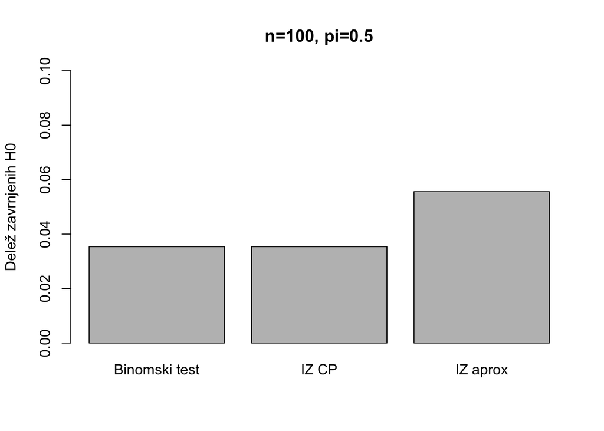

```r
rezultat = simuliraj(n=100,p0=0.5,runs=10000)
zavrnjeni = unlist(lapply(rezultat,FUN=function(x)sum(x)/length(x)))
barplot(zavrnjeni, ylab = "Delež zavrnjenih H0",
        names.arg = c("Binomski test","IZ CP", "IZ aprox"),main="n=100, pi=0.5",ylim=c(0,0.1))
```

Vidimo, da je pri vrednosti $\pi=0.5$ Clopper-Pearsonov IZ dualen binomskemu ekzaktnemu testu, aproksimativni interval pa ne (kar je pričakovano, saj velja samo, ko $n \rightarrow \infty$). Aproksimativni interval se za majhne vzorce odreže slabše (je celo liberalen).

Odmik od nominalne velikosti testa ($\alpha$) je pričakovan zaradi diskretnosti spremenljivke.

Izris deleža zavrnjenih $H_0$ za parametra $\pi = 0.08$ in $n = 100$.

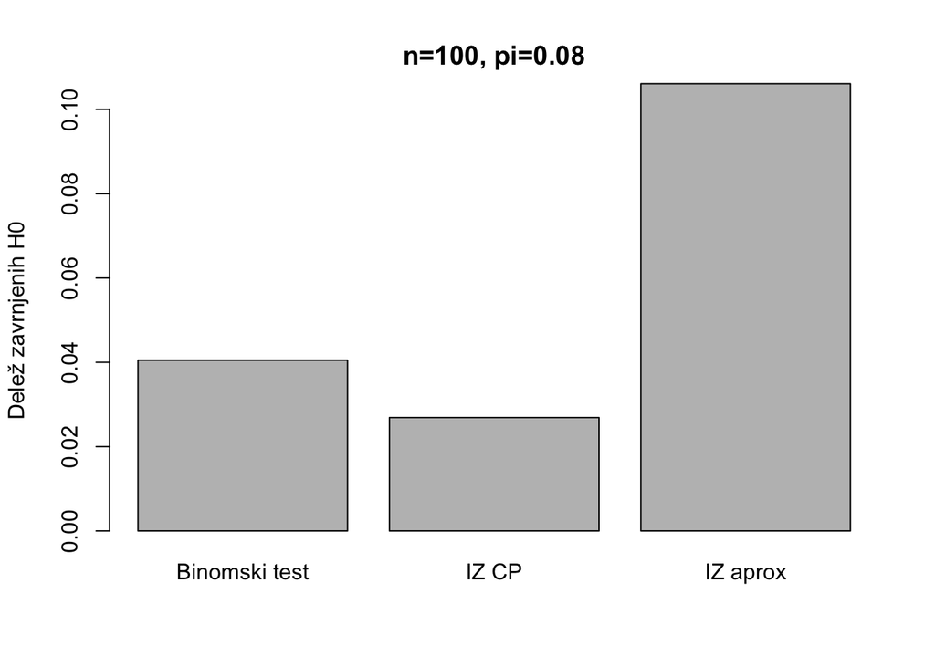

```r
rezultat = simuliraj(n=100,p0=0.08,runs=10000)
zavrnjeni = unlist(lapply(rezultat,FUN=function(x)sum(x)/length(x)))
barplot(zavrnjeni, ylab = "Delež zavrnjenih H0",
        names.arg = c("Binomski test","IZ CP", "IZ aprox"),main="n=100, pi=0.08",ylim=c(0,0.1))
```

Komentar - v tem primeru noben IZ ni dualen binomskemu eksaktnemu testu, kar je verjetno posledica odmika deleža od 0.5. Spet vidimo, da se aproksimativni interval odreže najslabše, kar je v največji meri posledica zelo majhne vrednosti $\pi$. Za vrednosti parametrov blizu roba definicijskega območja je predpostavka o normalni porazdelitvi tudi za velike $n$ kršena.

## 5. Deleži zavrnitev kot funkcija $\pi$ ($n=100$)

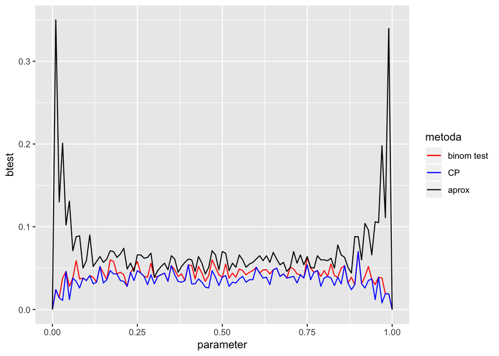

```r
# delež neujemanj glede na pi0 za n=100
aprox = NULL; CP = NULL; btest = NULL
parameter = seq(0,1,0.01)
for(pi in parameter){
  tmp = simuliraj(n=100,p0=pi,runs=1000)
  delez = unlist(lapply(tmp,FUN=function(x)sum(x)/length(x)))
  btest = append(btest,delez[1])
  CP = append(CP,delez[2])
  aprox = append(aprox,delez[3])
  #metoda = c("test","CP","aprox")
  #parameter = rep(pi,3)
  #rezPi = cbind(delez,metoda,parameter)
  #rezultati=rbind(rezultati,rezPi)
}

# REZULTAT v ggplot2
rezultati = data.frame(parameter,btest,CP,aprox)
ggplot(rezultati,aes(x=parameter)) +
         geom_line(aes(y=btest,colour="binom test")) +
         geom_line(aes(y=CP,colour="CP")) +
         geom_line(aes(y=aprox,colour="aprox")) +
         scale_colour_manual("metoda",
                      breaks = c("binom test", "CP", "aprox"),
                      values = c("black", "red", "blue"))
```

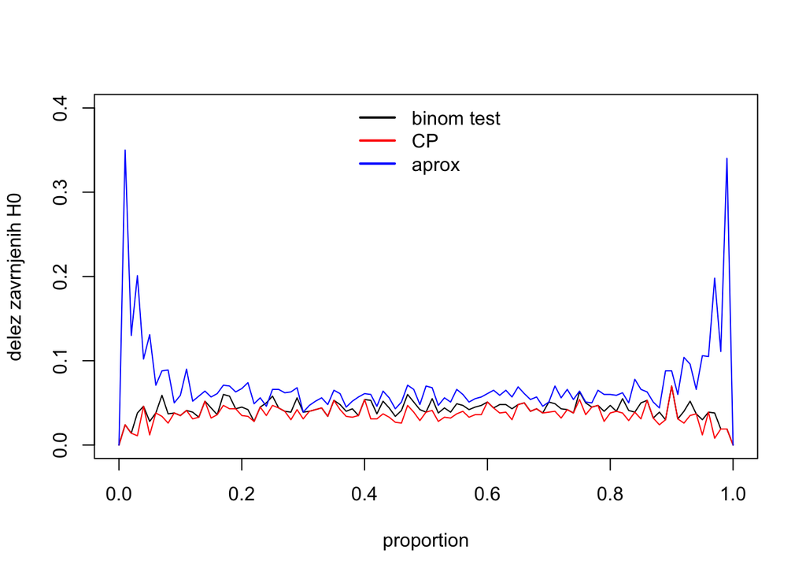

```r
# ENAK REZULTAT se na osnoven nacin
plot(parameter,btest,type="l",xlab="proportion",ylab="delez zavrnjenih H0",ylim=c(0,0.4))
lines(parameter,CP,type="l",col="red")
lines(parameter,aprox,type="l",col="blue")
legend("top",c("binom test","CP","aprox"),col=c("black","red","blue"),lwd=c(2,2),bty="n")
```

Zaradi diskretnosti porazdelitve pride do odstopanja velikosti testa od $\alpha = 0.05$. Vidimo, da je dualnost možna pri Clopper-Pearsonovem IZ, in sicer pri 0.5 in še nekaterih vrednostih $\pi$. Opazimo veliko odstopanje aproksimativnega IZ za majhne in velike vrednosti $\pi$. To je posledica dejstva, da na robovih definicijskega območja $\pi$ za nek fiksen $n$ porazdelitev ocen parametra $\hat{\pi}$ ne more biti več podobna normalni porazdelitvi.

## 6. Razlika z 99% IZ

Razmerje v razliki deleža zavrnjenih $H_0$ bi se pri posameznem $\pi$ lahko razlikovalo, saj velikost testa niha za različne vrednosti $n$ in $\pi$ (in seveda $\alpha$), zaključki pa bi bili verjetno podobni - tj. da je Clopper-Pearsonov IZ bližje dualnemu kot aproksimativni IZ in da je aproksimativni zelo slab ob robovih definicijskega območja $\pi$.